# TP1

Abdallah DAABOUL

17 mai 2019

# Exercice 1

## Q1

Le code proposé représente la loi (1/8 1/2 1/8 1/4) autrement dit, passé à l’un des 4 états avec les probas correspondantes.

## Q2

```r
EtatSuiv=function(i,Q){
  lg=length(Q)
  p=Q[i,]
  p1 = c(0, p[1:lg-1])
  t = runif(1)
  u = (t > cumsum(p1)) & (t < cumsum(p))
  X = which(u==1)
  return (X)
}
```

## Q3 - Etude d’une matrice irréductible et apériodique

### Partie a

```r
M=rbind(c(1/3, 1/3, 1/3), c(1/2, 0, 1/2),c(0, 1/2 , 1/2)) #Creation de la matrice
Etat=rep(NA,50)
Etat[1]=1  # Comme mu0=(1,0,0) on commence de l état 1
for(t in 2:50){     #n=50
Etat[t]=EtatSuiv(Etat[t-1],M)   #Je stocke l état à chaque itération
}
```

### Partie b

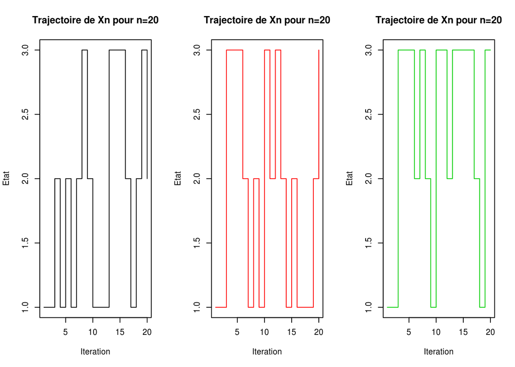

```r
Etat=rep(NA,20)
Etat[1]=1

par(mfrow=c(1,3))
for(Z in 1:3){
for(t in 2:20){     #n=20
  Etat[t]=EtatSuiv(Etat[t-1],M)   #Je stocke l état de chaque itération
}
Iteration=1:20
plot(Iteration,Etat,type="s",col=Z,main = "Trajectoire de Xn pour n=20")

}
```

### Partie c

Oui la matrice est irréductible parceque tout les états communiquent  
On remarque que nous pouvons remplacer le système pi*p=pi par p’pi’=pi’  
Alors le vecteur pi sera le vecteur correspondant à la valeur propre 1 .  
On divise pi par la somme de ses composantes pour avoir une somme de pi = 1

```r
tM=t(M) #Transposé de M
Propres=eigen(tM)
pi=Propres$vectors[,1] / sum(Propres$vectors[,1])
```

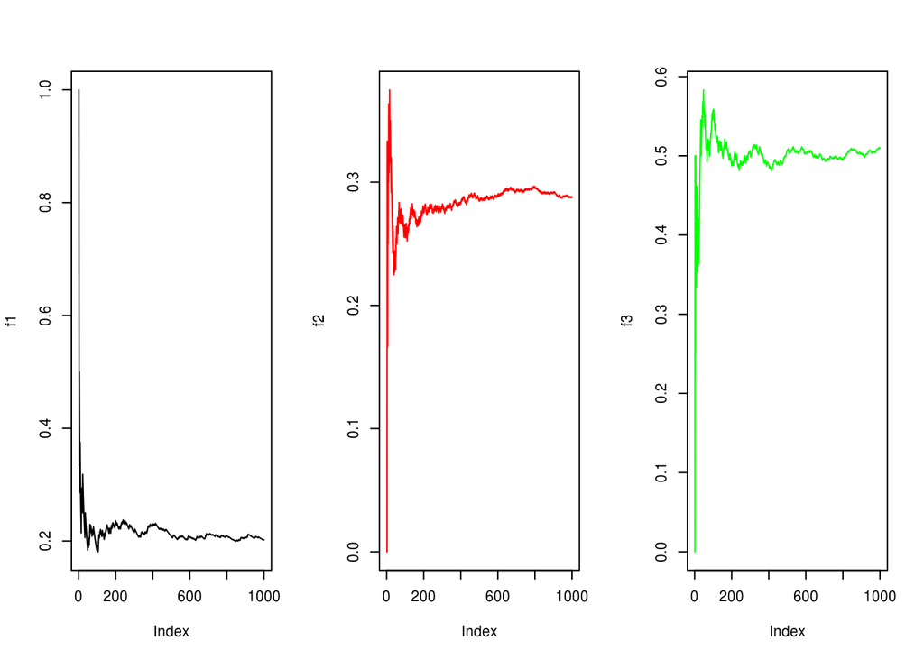

```r
#fonction qui simule n etat
simul <- function(n,M,P0){
  X = rep(0,times=n)
  l = length(M)
  p1 = c(0,P0[1:l-1])
  t = runif(1)
  u = (t > cumsum(p1)) & (t < cumsum(P0))
  X[1] = which(u==1)

  for(i in 2:n){
    X[i]=EtatSuiv(X[i-1],M)
  }
  return (X)
}
P0 = c(1,0,0)

T=seq(1,1000)
X = simul(1000,M,P0)
f1 = cumsum(X==1)/T
f2 = cumsum(X==2)/T
f3 = cumsum(X==3)/T

par(mfrow=c(1,3))
plot(f1,type='l')
plot(f2,type='l',col='red')
plot(f3,type='l',col='green')
```

Pour la convergence en loi  
Comme la matrice est apériodique alors on s’attend une convergence en loi

### Partie e

Periode = 1

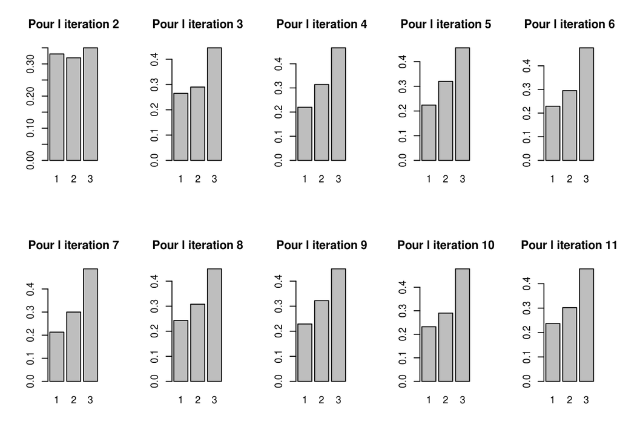

```r
#Simulation de 1000 trajectoires de 10 iteration (on prend 11 parceque la première est toujours 1)
Trajectoires=matrix(0,1000,11)
for(cpt in 1:1000){
  Trajectoires[cpt,] = simul(11,M,P0)
}
par(mfrow=c(2,5))
for(i in 2:11){
  barplot(table(Trajectoires[,i])/1000,beside=TRUE,main = paste('Pour l iteration',i))
}
```

Le barplot vérifie bien la convergence en loi, plus les itérations augmentent plus on converge a la loi stationnaire 0.23 0.30 0.461

## Q4

### Partie a

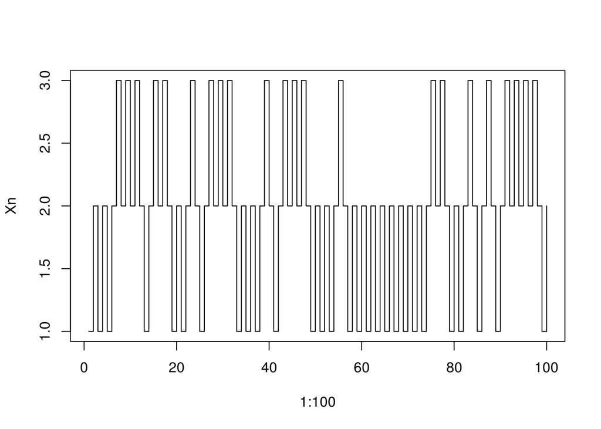

```r
par(mfrow=c(1,1))
Q=rbind(c(0, 1, 0), c(1/2, 0, 1/2),c(0, 1 , 0)) #Creation de la matrice Q
#Trajectoire
Xn=simul(100,Q,P0)
plot(1:100,Xn,type="s")
```

### Partie b

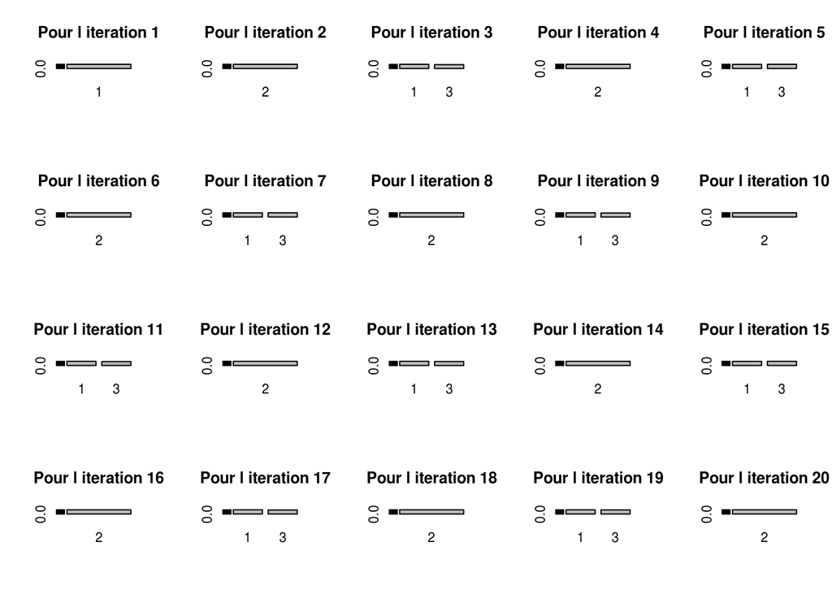

```r
#Simulation de 1000 trajectoires de 10 iterations (on prend 11 parceque la première est toujours 1)
Trajectoires=matrix(0,1000,20)
for(cpt in 1:1000){
Trajectoires[cpt,] = simul(20,Q,P0)
}
par(mfrow=c(4,5))
for(i in 1:20){
barplot(table(Trajectoires[,i])/1000,beside=TRUE,main = paste('Pour l iteration',i))
}
```

Les histogrames verifient bien la matrice Q Etant dans l’état 1 ou 3 on est oblige d’aller à l’état 2 Etant dans l’état 2 on a la même chance d’aller à l’état 1 ou 3  
Partant de 1 :  
à une iteration pair on est obligé d’être dans l’état 2 à une itération impaire on on est soit en 1 soit en 3 (50% 50%) Et comme le barplot itère entre 2 modèles alors on a pas une convergence en loi (question 4a)  
X(2k)—> (0 1 0) X(2k+1)—>(0.5 0 0.5)

## Q5 - Etude d’une matrice non irréductible

### Partie(a)

```r
R=rbind(c(0.5,0.5,0,0),c(0.5,0.5,0,0),c(0,0,2/3,1/3),c(0,0,1/4,3/4))
Xn=simul(100,R,P0)
```

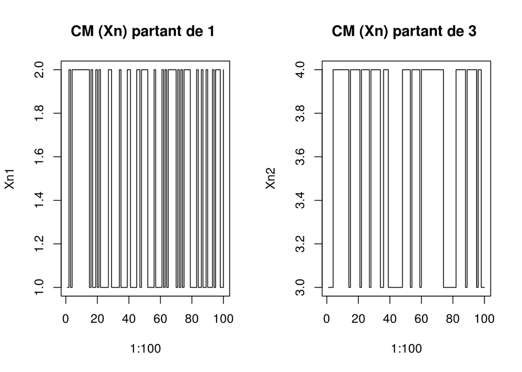

```r
P0=c(1,0,0,0)
P0prime=c(0,0,1,0)


par(mfrow=c(1,2))
Xn1=simul(100,R,P0)
plot(1:100,Xn1,type='s',main = "CM (Xn) partant de 1 ")
Xn2=simul(100,R,P0prime)
plot(1:100,Xn2,type='s',main = "CM (Xn) partant de 3 ")
```

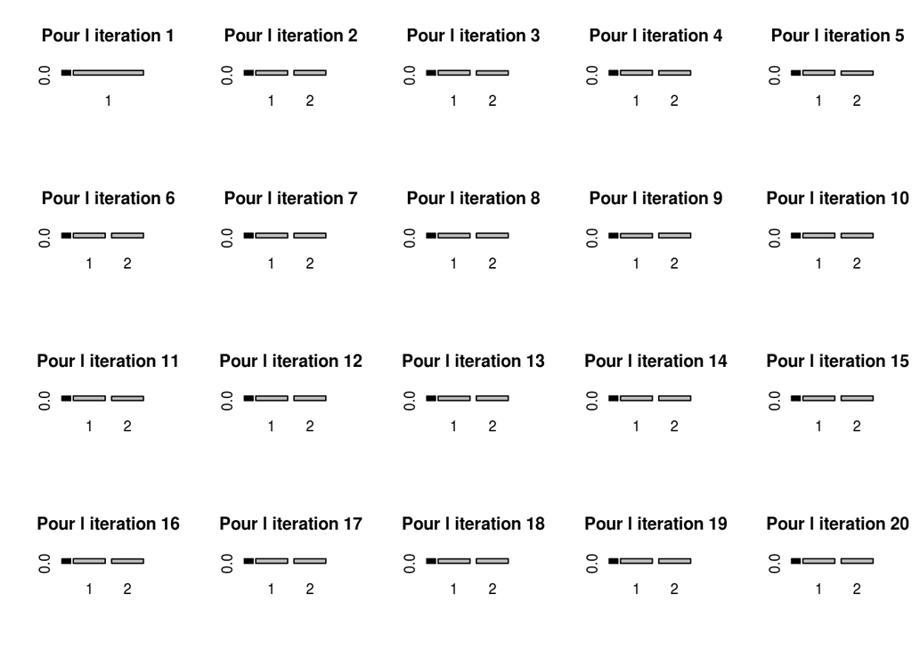

```r
#p0
vect3=matrix(NA,1000,20)
for(i in 1:1000){
  vect3[i,]=simul(20,R,P0)
}

par(mfrow=c(4,5))
for(i in 1:20){
  barplot(table(vect3[,i])/1000,beside=T,main=paste('Pour l iteration',i))
}
```

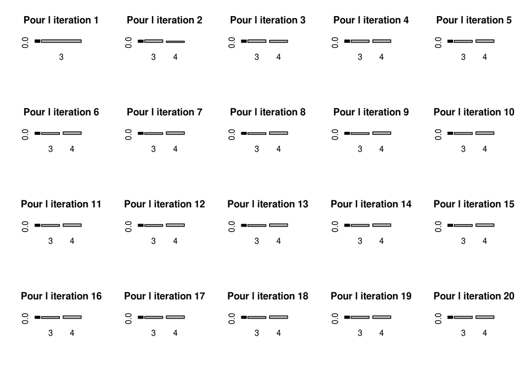

```r
#p0prime
vect4=matrix(0,1000,20)
for(i in 1:1000){
  vect4[i,]=simul(20,R,P0prime)
}

par(mfrow=c(4,5))
for(i in 1:20){
  barplot(table(vect4[,i])/1000,beside=T,main=paste('Pour l iteration',i))
}
```

D’après les deux dernière questions, on peut remarquer que la loi converge soit dans la première classe de recurrence (1,2), soit dans la deuxième(3,4), donc on a pas une convergence en loi

# Exercice 2

## Q1

### Construction de la fonction malz

```r
malz=function(x0,p,n){
  x=rep(NA,n)
  x[1]=x0
  if(n>1){
  for (i in 2:n) {
    u=runif(1)
    x[i]=x[i-1]-1*(u>p)+1*(u<=p)
  }

  }
  return(x)
}
```

## Q2

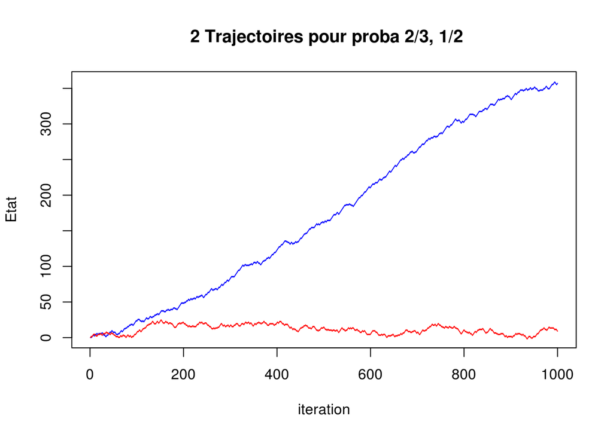

```r
marche1=malz(0,2/3,1000)
marche2=malz(0,1/2,1000)
iteration=1:1000
plot(iteration,marche1,type = "l",main=paste(" 2 Trajectoires pour proba 2/3, 1/2"),ylab = "Etat",col="blue")
lines(iteration,marche2,type = "l",col="red")
```

Nous remarquons que la courbes rouge ( p=0.5) reste presque stable et varie très peu autour de sa position initiale. Tandis que la courbe bleu augmente à cause de la proba elevé (0.666) pour monter d’état.

## Q3

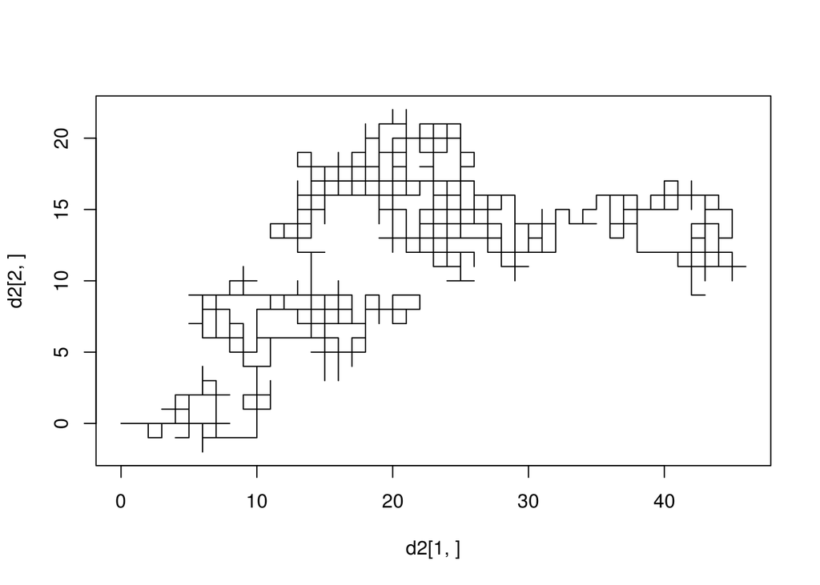

```r
MAIZd <- function(N,d){
        X=matrix(rep(NA,N*d),nrow=d)
        X[,1]=matrix(0,d,1)
        for(i in 2:N){
            composante=runif(1,0,d)
            sens=runif(1)
            Zn=matrix(0,d,1)
            Zn[floor(composante)+1]=(sens>0.5)-(sens<0.5)
            X[,i]=X[,i-1]+Zn
        }
        return(X)
}

NormeM <- function(A){
    V=rep(NA,dim(A)[2])
    for(i in 1:length(V)){
        V[i]=norm(t(A[,i]),"F")
    }
    return(V)
}


d2=MAIZd(1000,2)
plot(d2[1,],d2[2,],type='l')
```

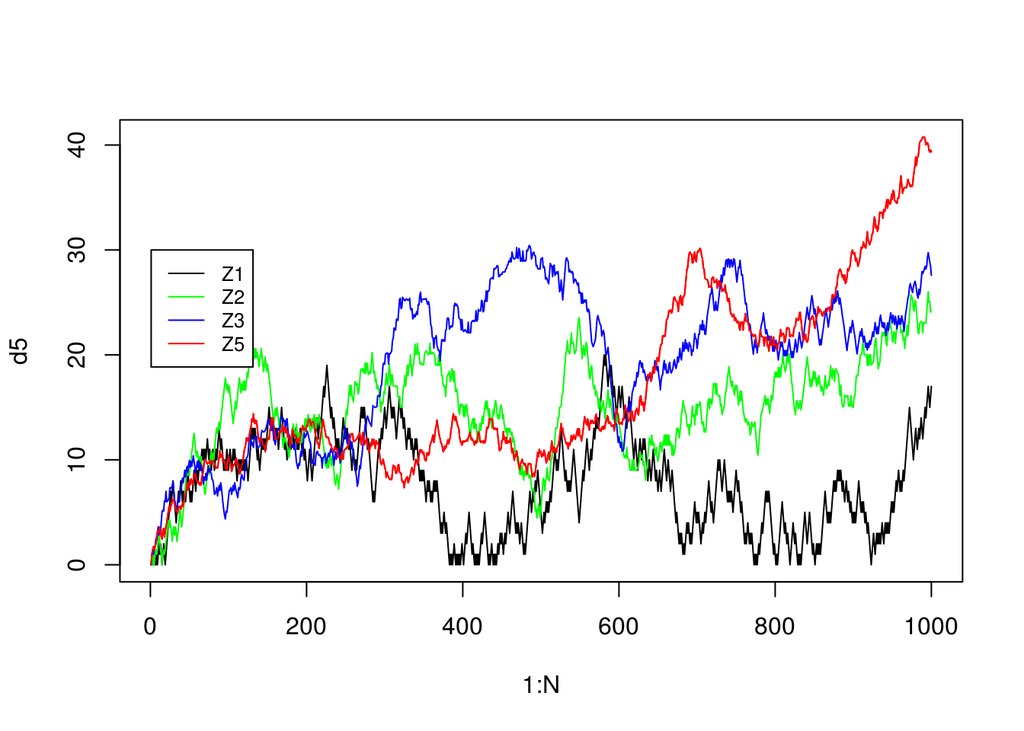

```r
N=1000
d1=NormeM(MAIZd(N,1))
d2=NormeM(MAIZd(N,2))
d3=NormeM(MAIZd(N,3))
d5=NormeM(MAIZd(N,5))
plot(1:N,d5,col="red",type='l')

lines(1:N,d1,type='l')
lines(1:N,d2,col="green",type='l')
lines(1:N,d3,col="blue",type='l')
lines(1:N,d5,col="red",type='l')
legend(1, 30, legend=c("Z1", "Z2","Z3","Z5"),
       col=c("black","green","blue", "red"), lty=1, cex=0.8)
```